# Getting Started in R

## R for Python People

```python
print("Hello, Data^3 Python People!")
```

```
## Hello, Data^3 Python People!
```

```r
"And to you also, R Folks!"
```

```
## [1] "And to you also, R Folks!"
```

I'm orienting this talk to people who are familiar with programming … but not necessarily either R or Python.

## Tips for Getting Started

1. Where to start?
2. How to move forward?
3. What should I skip until I need it?

## Many, many resources

- **c<>de school** http://tryr.codeschool.com/
- *The Art of R Programming* Norman Matloff
- *Introduction to R* Michael Clark http://www3.nd.edu/~mclark19/learn/Introduction_to_R.pdf
- http://www.johndcook.com/blog/r_language_for_programmers/
- http://en.wikibooks.org/wiki/R_Programming/Introduction
- *An Introduction to R* Venables, Smith & R Core Team

## My approach today

You can read the previously listed resources at any time.

Little point in my repeating them here.

**Instead …**

An unconventional introduction …

- Cover the minimum of language constructs and issues
- Provide support for doing actual work
- Get you going quickly so that you can learn more by reading examples.

presentation sources at  
http://github.com/dtkaplan/Data-3-Conference

## Ten Starting Steps

### Preliminaries

- 1: Start with documents
- 2: Simple R chunks within documents
- 3: Atomic types
- 4: Assignment & naming (trivial)
- 5: Vectors
- 6: Packages

### Data Science

- 7: Data frames
- 8: Wrangling
- 9: Graphics
- 10: Programming constructs

### Now you're ready to

- read other people's examples and documentation
- copy and modify to your own purposes

## Step 1: Start with Documents

Within RStudio, use the editor to create Markdown documents.

- Open a document using NewFile/RMarkdown/Document: use the defaults.
- Compile to HTML

[figure not shown]

### A level 3 heading

Narrative looks like this.

- Bullet points
- **bold** and *italics*
1. Numbered list
   - Sublist item one
   - Sublist item two
2. Another item
3. [A link](http://www.macalester.edu)

```
### A level 3 heading

Narrative looks like this.

* Bullet points
* **bold** and *italics*

1. Numbered list
    * Sublist item one
    * Sublist item two
#. Another item
#. [A link](http://www.macalester.edu)
```

## Step 2: Add simple R chunks

Start with some arithmetic.

```r
3 + 5
```

```
[1] 8
```

### Numerics

```r
3 / 0
```

```
[1] Inf
```

````
Start with some arithmetic.

```{r}
3 + 5
```

### Numerics

```{r}
3 / 0
```
````

## Step 3: "Atomic" types

| String | Numeric | Logical |
| --- | --- | --- |
| `"Hello, World!"` | `5`, `3.76`, `1.2e12` | `TRUE`, `FALSE` |

| type | basic operators |
| --- | --- |
| strings | manipulation: `paste()`, `tolower()` |
|  | comparison: `== > < <= >=` |
| numbers | arithmetic: `+ - * / %%` and so on |
|  | mathematical, e.g. `sin()` |
|  | comparison `> < == <= >=` |
| logical | `\| & ! xor()` |

## Step 4: Assignment and Naming

People in the audience already know about objects, object names, and assignment.

```r
x <- 3 + 4
country_name <- "Italy"
position3 <- 17
```

But not `country name` or `3position`

Named arguments are like Python optional arguments, e.g. `seq(0, 5, length=26)`

## Step 5: Vectors

```r
my_vec <- c(4, 5, 6)
sqrt(my_vec)
```

```
[1] 2.000000 2.236068 2.449490
```

```r
sum(my_vec)
```

```
[1] 15
```

```r
paste("Person", my_vec)
```

```
[1] "Person 4" "Person 5" "Person 6"
```

### An Important Distinction

**Reduction Functions**:  
Reduce a vector to a single element `mean()`, `max()`, `min()`, `sd()`, `sum()`, `all()`, `any()`

**Transformation Functions**: Operate on each element of a vector

- Unary: `sqrt()`, `sin()`, etc.
- Binary: `+ / - * ^ == > <`, etc.

Element-by-element combination of a vector and a scalar or of a vector with a vector, e.g.

```r
my_vec ^ sqrt(my_vec)
```

```
[1] 16.00000 36.55480 80.55148
```

## Step 6: Packages

To use installed packages:

1. `library(dplyr)` — access to everything in package
2. `dplyr::mutate()` — access to one function

For upcoming examples:

```r
library(dplyr) # for wrangling
library(ggplot2) # for graphics
library(leaflet) # for maps
library(rvest) # for html/xml scraping
```

### To install

Vetted packages on "CRAN" and many others on, e.g. GitHub

A one-time operation.

1. RStudio tab: Packages/Install for CRAN.
2. From e.g. GitHub: `devtools::install_github("dtkaplan/mosaic")`

## Step 7: Data

Data Frame: a collection of vectors, each of the same length. This represents a rectangular "spreadsheet" array of data.

```r
head(mtcars, 2)
```

```
              mpg cyl disp  hp drat    wt  qsec vs am gear carb
Mazda RX4      21   6  160 110  3.9 2.620 16.46  0  1    4    4
Mazda RX4 Wag  21   6  160 110  3.9 2.875 17.02  0  1    4    4
```

```r
nrow(mtcars)
```

```
[1] 32
```

```r
names(mtcars)
```

```
 [1] "mpg"  "cyl"  "disp" "hp"   "drat" "wt"   "qsec" "vs"
 [9] "am"   "gear" "carb"
```

```r
with(mtcars, mean(mpg))
```

```
[1] 20.09062
```

For quick look: `str(mtcars)`, `summary(mtcars)`, `View(mtcars)`

Read in data from

- tidy CSV files. (Scraping for later.)

  ```r
  options(stringsAsFactors=FALSE)
  MyData <- read.csv(file.choose()) # one off
  MyData <- read.csv("~//Talks/2015-03-07-Data3/bikedata.csv")
  MyData <- read.csv(
    url("http://www/mosaic-web.org/go/datasets/CPS85.csv")
    )
  ```

- package data (for learning, testing, …)

  ```r
  mosaicData::Births78
  ```

Example: Capital BikeShare

[figure not shown]

Bike sharing system in Washington, DC.

```r
BikesRaw <- read.csv("BikeShare/2014-Q4-Trips-History-Data.csv")
# Bikes is lightly cleaned: see below
head(Bikes,2)
```

```
                sdate                        sstation bikeno
1 2014-10-01 00:00:00         Wisconsin Ave & O St NW W20503
2 2014-10-01 00:01:00 Columbus Circle / Union Station W20487
```

```r
names(Bikes)
```

```
[1] "duration" "sdate"    "sstation" "edate"    "estation"
[6] "bikeno"   "client"
```

## Step 8: Data Wrangling

Start with `dplyr` package. Provides concise interface to relational operations.

### Data verbs

Data verbs take a data frame as input and return a data frame as output.

- `filter()` — selects by criteria
- `summarise()` — aggregates
- `group_by()` — sets reduction operations by groups
- `inner_join()` and other joins — combine two tables
- `mutate()` — creates new variables from old

Others: `arrange()`, `select()`, `sample_n()`, …

Task: Count number of bikes picked up at each station

```r
PickedUp <-
  Bikes %>%
  group_by(sstation) %>%
  summarise(picked_up = n())
DroppedOff <-
  Bikes %>%
  group_by(estation) %>%
  summarize(dropped_off = n())
Activity <-
  inner_join(PickedUp, DroppedOff, by=c("sstation"="estation")) %>%
  arrange(desc(picked_up))
```

```
                              sstation picked_up dropped_off
1      Columbus Circle / Union Station     15876       16209
2 Massachusetts Ave & Dupont Circle NW     13056       15351
3                     Lincoln Memorial      9984        9833
4                        Thomas Circle      9597        8645
5                       15th & P St NW      9123       10202
6          New Hampshire Ave & T St NW      9077        8153
```

## Step 9: Graphics

Start with `ggplot2` package.

- `ggplot()` defines a "frame"
- `aes()` maps variables to graphical attributes
- geom set the glyph type

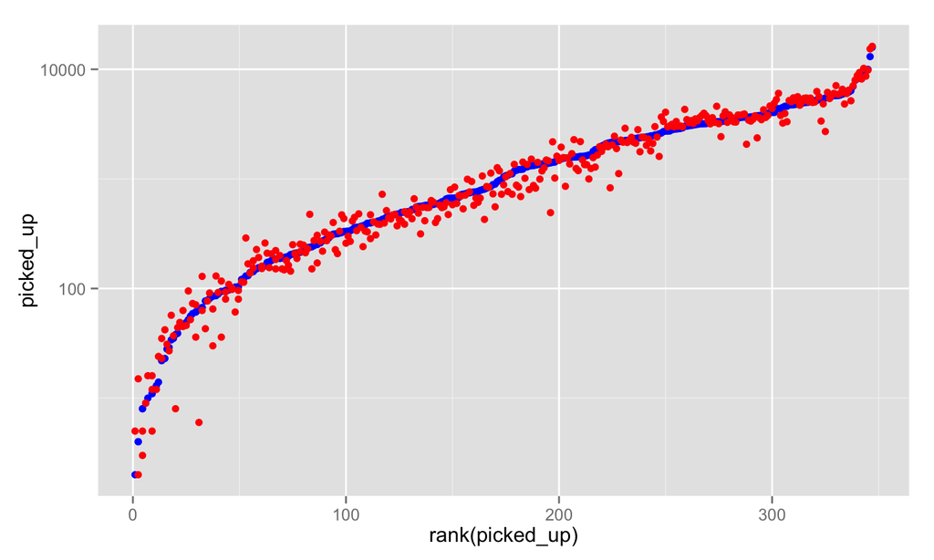

```r
Activity %>%
  ggplot(aes(x = rank(picked_up), y = picked_up)) +
  geom_point(color = "blue") +
  geom_point( aes(y = dropped_off), color = "red") +
  scale_y_log10()
```

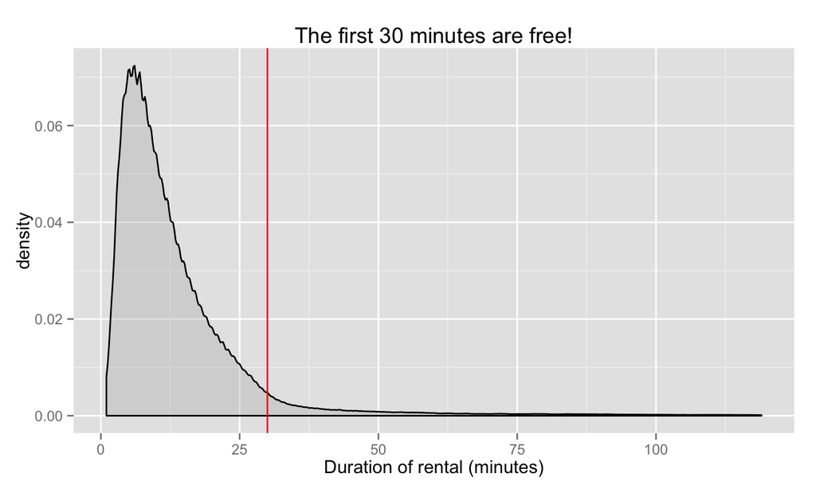

```r
Bikes %>%
  mutate(dur = as.numeric(edate - sdate) / 60) %>%
  filter(dur > 0, dur < 120) %>%
  ggplot(aes(x = dur)) +
  geom_density(alpha=0.4, fill="gray") +
  xlab("Duration of rental (minutes)") +
  ggtitle("The first 30 minutes are free!") +
  geom_vline(x=30, color="red")
```

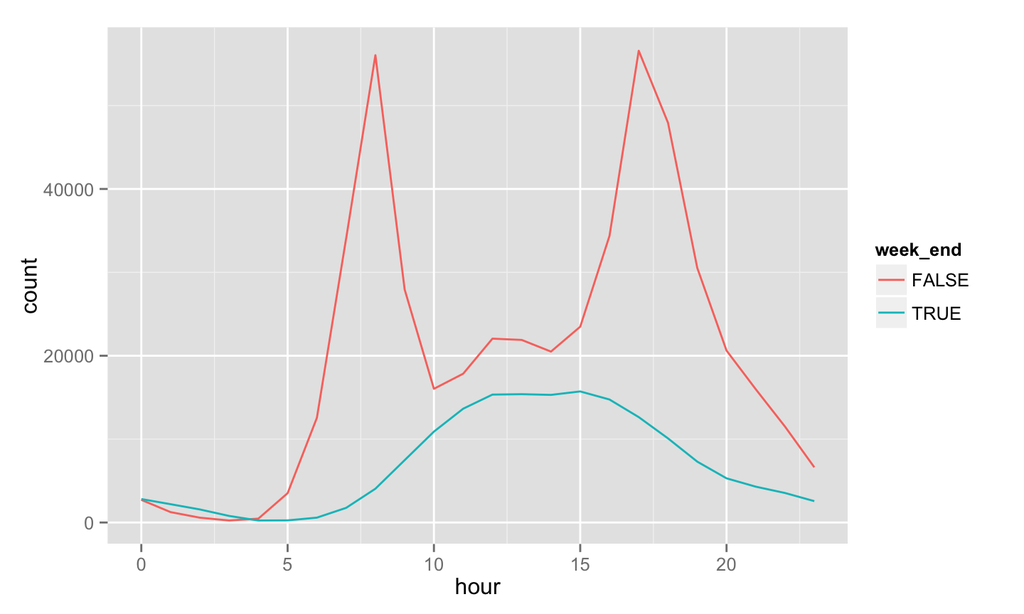

```r
Bikes %>%
  mutate(week_end = weekdays(sdate, TRUE) %in% c("Sat", "Sun"),
         hour = lubridate::hour(sdate) ) %>%
  group_by(hour, week_end) %>%
  summarise(count = n()) %>%
  ggplot(aes(x = hour, y = count, group = week_end)) +
  geom_line(aes(color = week_end))
```

## Step 10: Programming constructs

1. Conditionals `ifelse(count > 100, "big","small")`
2. Functions `f <- function(x) {x^2}`
3. Loops `for (s in stations) {` do something with s `}`
4. Indexing
5. Matrices
6. Lists

Scraping the XML station data

```
<stations lastUpdate="1425503108846" version="2.0">
  <station>
    <name>20th &amp; BellSt</name>
    <lat>38.8561</lat><long>-77.0512</long>
    <nbBikes>7</nbBikes><nbEmptyDocks>4</nbEmptyDocks>
  </station>
  ...
```

```r
myvars <- function(station) {
    xml_nodes(station,
              xpath=c("lat","long","nbbikes","nbemptydocks","name")
    ) %>% xml_text     }

station_nodes <- xml("BikeShare/bikeStations.xml") %>%
                 xml_nodes("station")
Stations <-
  sapply(station_nodes, myvars) %>% t %>%
  data.frame(stringsAsFactors=FALSE)
names(Stations) <- c("name","lat","long","nbBikes","nbEmptyDocks")
```

## Read examples and imitate

A map of bicycle sharing stations showing

- availability of bikes
- empty docks to return bikes.

```r
stationMap <-
  leaflet(Stations) %>%   # like ggplot()
  addTiles() %>%          # add the map
  setView(-77.04, 38.9, zoom=12) %>%
  addCircleMarkers(radius=Stations$nbBikes) %>%
  addCircleMarkers(radius=pmax(0,Stations$nbEmptyDocks), color="red")
```

[interactive chart not shown]